# Assignment 6

## Try to submit as an HTML file

Print your Emory code below

```python
print("laking8")
```

```
laking8
```

Import the "pandas" and "matplotlib.pyplot" libraries

```python
# Write your answer here:

import pandas as pd
import matplotlib.pyplot as plt
import os as os
```

(a) Functions

- Read the dataset labelled features.csv.
- Create a `lambda` function that checks if displacement $>$ 200
- Create a new list that shows true if displacement $>$ 200 and false  
  if displacement $\leq$ 200.
- Count how many cars have displacement $> 200$.

To get full credit use either the apply or the map function  
(see Lectures 7 and 8)

```python
# Write your answer here:

#I was getting some errors doing file recall so I just made sure that I was in the right working directory
#get wd
current_directory = os.getcwd()
#print wd
print(current_directory)

# Read the features.csv file
features = pd.read_csv("data/features.csv")

# Lambda function that checks if displacement > 200
features_displacement = lambda displacement: displacement > 200

# Creating an empty list
new_list = []

# Apply the lambda function and append the result to the list
# Apply the lambda function to the displacement column and create a new list
new_list = features["displacement"].apply(features_displacement).tolist()

# Count how many cars have displacement > 200; this works because the sum function should treat "True" as 1, and "False" as zero
original_count = sum(new_list)

# Print the result
print("Number of cars with displacement > 200:", original_count)
```

```
/Users/lydiaking/Documents/GitHub/qtm151spring2025/Assignments/assignment6
Number of cars with displacement > 200: 158
```

(b) Subsetting Data

- Read the dataset labelled features.csv.
- Define a global variable called `threshold` that takes the  
  value 2588
- Subset the data to get one dataset with weight $>$ threshold and  
  another with weight $\le$ 2588. Use the `.query()` function.
- Compute the mean acceleration for each of these datasets.

Note: Review how to define a gloabl variable inside `.query()`

```python
# Write your answer here:

#read dataset labeled features.csv
features = pd.read_csv("data/features.csv")

#define a global variable called threshold that takes value 2588
threshold = 2588

#subset according to stipulated conditions using .query
subset_features_1 = features.query("weight > @threshold")

subset_features_2 = features.query("weight <= 2588")

#compute mean acceleration for each dataset

print(" the mean for weight > threshold is " + str(subset_features_1["acceleration"].mean()))

print(" the mean for weight <= 2588 is " + str(subset_features_2["acceleration"].mean()))
```

```
 the mean for weight > threshold is 14.972457627118644
 the mean for weight <= 2588 is 16.435802469135812
```

(c) Use sorting + ".iloc[]"

- Read the "fifa23_players_basic.csv" dataset
- Use ".sort_values()" to order the "Age" column  
  from youngest to oldest
- Get a subset with the 5 youngest players

```python
# Write your answer here:

#read fifa
fifa23 = pd.read_csv("data/fifa23_players_basic.csv")

#use sort values for age column
fifa_ascending_age = fifa23.sort_values(by = "Age")

#subset for 5 youngest players
display (fifa_ascending_age.iloc [0:5, :])
```

|  | Known As | Full Name | Overall | Potential | Value(in Euro) | Positions Played | Best Position | Nationality | Image Link | Age | ... | Preferred Foot | Weak Foot Rating | Skill Moves | International Reputation | National Team Name | National Team Image Link | National Team Position | National Team Jersey Number | Attacking Work Rate | Defensive Work Rate |
| --- | --- | --- | --- | --- | --- | --- | --- | --- | --- | --- | --- | --- | --- | --- | --- | --- | --- | --- | --- | --- | --- |
| 17956 | A. Dithmer | Andreas Dithmer | 53 | 76 | 275000 | GK | GK | Denmark | https://cdn.sofifa.net/players/269/573/23_60.png | 16 | ... | Right | 2 | 1 | 1 | - | https://cdn.sofifa.net/flags/dk.png | - | - | Medium | Medium |
| 18014 | J. Ardila | José Ardila | 53 | 73 | 250000 | CM | CAM | Venezuela | https://cdn.sofifa.net/players/268/892/23_60.png | 16 | ... | Right | 3 | 2 | 1 | - | https://cdn.sofifa.net/flags/ve.png | - | - | Medium | Medium |
| 16084 | S. Ngoma | Serge Ngoma | 58 | 82 | 650000 | RW | RM | United States | https://cdn.sofifa.net/players/267/796/23_60.png | 16 | ... | Right | 3 | 2 | 1 | - | https://cdn.sofifa.net/flags/us.png | - | - | High | Medium |
| 11481 | O. Vargas | Obed Vargas | 64 | 81 | 1500000 | CM,CDM,RM | CAM | United States | https://cdn.sofifa.net/players/263/701/23_60.png | 16 | ... | Right | 3 | 3 | 1 | - | https://cdn.sofifa.net/flags/us.png | - | - | High | Medium |
| 17591 | A. Madaliński | Alan Madaliński | 54 | 68 | 210000 | GK | GK | Poland | https://cdn.sofifa.net/players/270/590/23_60.png | 16 | ... | Right | 3 | 1 | 1 | - | https://cdn.sofifa.net/flags/pl.png | - | - | Medium | Medium |

5 rows × 32 columns

(d) Use queries + global variables

- Read the "fifa23_players_basic.csv" dataset
- Compute the mean of the column "Wage(in Euro)"  
  and store it as a variable
- Subset the players whose value is above the mean value  
  using ".query()"

HINT: Remember that there is a special syntax for  
when the column names have spaces (see Lecture 10)  
Reference the column as `` `Wage(in Euro)` `` inside .query()

```python
# Write your answer here:

#read fifa
fifa23 = pd.read_csv("data/fifa23_players_basic.csv")

#Compute mean of "Wage(in Euro)" and store as a variable
fifa_mean_wage = fifa23["Wage(in Euro)"].mean()

#subset players whose value is above mean value
fifa_above_average_wage = fifa23.query("`Wage(in Euro)` > @fifa_mean_wage" )
```

[output not shown]

(e) Plot by Category

Read the "data/wdi_urban.csv" dataset.

This contains data from 1980 and 2020.

- **Create a list with the unique values of "year"**
- **Create a plot with a ...**
  - Histogram of "prop_urbanpopulation" for each year
  - Set the histogram option `alpha = 0.5` for transparency
  - All the histograms should be overlapping
  - Create a legend with the list of years
  - Label the axes and the title

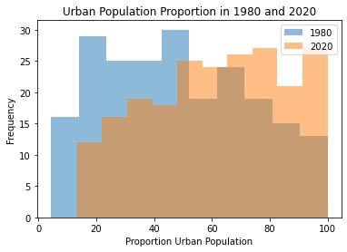

```python
# Write your answer here:

# Read the urban dataset
urban = pd.read_csv("data/wdi_urban.csv")

# Create a list with unique values of "year"
list_urban_unique = pd.unique(urban["year"])

# Plotting histograms
for year in list_urban_unique:
    df = urban.query("year == @year")
    plt.hist(df["prop_urbanpopulation"], alpha=0.5, label=str(year))

# Label the axes and title
plt.xlabel("Proportion Urban Population")
plt.ylabel("Frequency")
plt.title("Urban Population Proportion in 1980 and 2020")

# Create a legend
plt.legend()

# Show the plot
plt.show()
```